# Análise de Desempenho Educacional - MA

> Objetivo: segmentar municípios por contexto socioeconômico e, dentro de cada grupo, identificar fatores associados aos destaques de IDEB.

Este notebook está alinhado com o script `src/analytics.py` e organizado em passos curtos.

Fluxo da análise:

1. Carregamento e checagem dos dados
2. Diagnóstico de clusterização (Elbow, Silhouette, PCA)
3. Clusterização final (k=2) e descrição dos grupos
4. Relevância de variáveis para diferenciar destaques no IDEB por cluster
5. Comparação de perfis e testes de Mann-Whitney
6. Gráficos finais para relatório

## 1) Carregamento e pré-processamento

> Neste passo você confere a base consolidada e prepara as variáveis para clustering.

Observação metodológica:

- Os clusters são formados apenas com variáveis socioeconômicas (`RENDA_PER_CAPITA_2022` e `PCT_POBREZA_EXTREMA_2022`).
- IDEB e demais variáveis entram depois para interpretação intracluster.

```python
import importlib
import pandas as pd
import analytics

importlib.reload(analytics)

print('Arquivo de entrada:', analytics.TRUSTED_DIR / 'indicadores_municipais_ma.csv')
df = analytics.carregar_dados()

print('Shape:', df.shape)
print('Municipios unicos:', df['NO_MUNICIPIO'].nunique())
print('\nVariaveis de cluster (socioeconomicas):', analytics.VARS_CLUSTER)
print('\nNulos nas variaveis de cluster:')
print(df[analytics.VARS_CLUSTER].isna().sum())

df[['NO_MUNICIPIO', 'RENDA_PER_CAPITA_2022', 'PCT_POBREZA_EXTREMA_2022', 'VL_OBSERVADO_2025']].head()
```

```
Arquivo de entrada: /media/dados/aplicacoes/git/mestrado/Artigos/desempenho-educacional-maranhao/data/trusted/indicadores_municipais_ma.csv
Shape: (217, 41)
Municipios unicos: 217

Variaveis de cluster (socioeconomicas): ['RENDA_PER_CAPITA_2022', 'PCT_POBREZA_EXTREMA_2022']

Nulos nas variaveis de cluster:
RENDA_PER_CAPITA_2022       0
PCT_POBREZA_EXTREMA_2022    0
dtype: int64
```

|  | NO_MUNICIPIO | RENDA_PER_CAPITA_2022 | PCT_POBREZA_EXTREMA_2022 | VL_OBSERVADO_2025 |
| --- | --- | --- | --- | --- |
| 0 | AÇAILÂNDIA | 1007.41 | 15.90 | 5.7 |
| 1 | AFONSO CUNHA | 605.56 | 39.26 | 5.1 |
| 2 | ÁGUA DOCE DO MARANHÃO | 597.92 | 37.46 | 5.9 |
| 3 | ALCÂNTARA | 681.48 | 31.02 | 5.0 |
| 4 | ALDEIAS ALTAS | 533.46 | 44.19 | 5.2 |

## 2) Diagnóstico de clusters

> Avalia diferentes valores de `k` e visualiza a separação dos grupos.

Leitura esperada:

- Elbow/Silhouette ajudam a justificar o número de clusters.
- PCA mostra se os grupos estão visualmente separáveis.

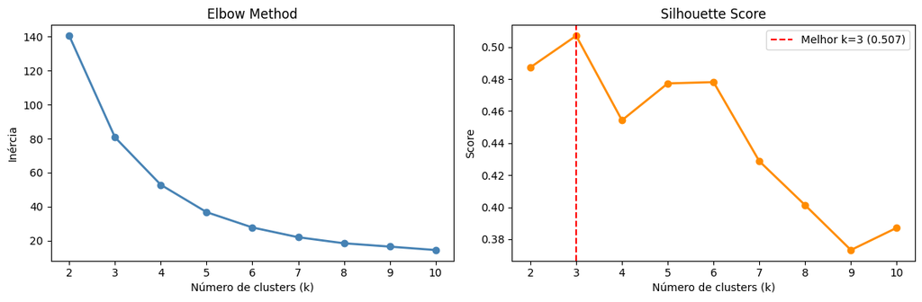

```
Melhor k pelo Silhouette: 3 (score: 0.507)

Todos os scores:
  k=2: 0.487
  k=3: 0.507
  k=4: 0.454
  k=5: 0.477
  k=6: 0.478
  k=7: 0.429
  k=8: 0.401
  k=9: 0.373
  k=10: 0.387
```

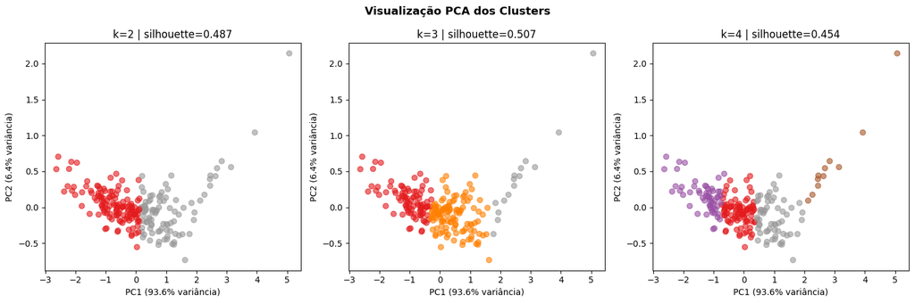

```
Valor configurado no pipeline para cluster final: 2
```

```python
X_scaled, _ = analytics.normalizar(df)
k_range = range(2, 11)

# Grafico Elbow + Silhouette (mostra em tela)
silhouettes = analytics.elbow_silhouette(X_scaled, k_range, salvar_arquivo=False)

# Visualizacao em PCA para k=2,3,4
analytics.visualizar_pca(X_scaled, silhouettes, k_range, salvar_arquivo=False)

print('\nValor configurado no pipeline para cluster final:', analytics.CLUSTER_K)
```

## 3) Clusterização final e leitura dos grupos

> Executa a clusterização final (`k=2`) e lista os municípios destaque por IDEB em cada cluster.

Interpretação:

- `vulneráveis`: grupo com menor renda média
- `maior renda`: grupo com melhor contexto socioeconômico médio

```python
df_cluster = analytics.clusterizar(df.copy(), X_scaled, k=analytics.CLUSTER_K)

# Top e bottom IDEB dentro de cada cluster
analytics.destacar_municipios_por_cluster(df_cluster, top_n=5)

# Outliers positivos por cluster
analytics.outliers_positivos(df_cluster)
```

```
Tamanho dos clusters:
CLUSTER_NOME
vulneráveis    127
maior renda     90
dtype: int64

Cluster vulneráveis — municípios (127):
                NO_MUNICIPIO  RENDA_PER_CAPITA_2022  VL_OBSERVADO_2025
                  CANTANHEDE                 737.41                6.0
                 SANTA LUZIA                 712.85                5.8
                    SAMBAÍBA                 703.14                6.8
                    CURURUPU                 699.05                4.7
           SUCUPIRA DO NORTE                 694.83                5.4
                       AXIXÁ                 692.03                7.1
                   ALCÂNTARA                 681.48                5.0
                    BEQUIMÃO                 679.09                5.0
     GOVERNADOR NUNES FREIRE                 678.51                5.3
                  CARUTAPERA                 676.39                5.6
                     ROSÁRIO                 675.16                5.8
     ALTO ALEGRE DO MARANHÃO                 671.08                4.7
      PORTO RICO DO MARANHÃO                 671.08                4.6
                 COELHO NETO                 671.03                6.1
                  JOSELÂNDIA                 669.96                5.5
                 PAULO RAMOS                 668.82                5.2
                  SÍTIO NOVO                 668.73                5.3
                  SANTA RITA                 667.41                5.5
                  BURITICUPU                 667.09                4.7
                  PERI MIRIM                 665.56                5.3
                  LAGO VERDE                 665.18                4.8
                     FORTUNA                 663.54                5.4
           PRESIDENTE MÉDICI                 663.31                5.7
     SENADOR ALEXANDRE COSTA                 661.54                5.0
        MAGALHÃES DE ALMEIDA                 660.15                5.6
      FORMOSA DA SERRA NEGRA                 658.60                5.8
             ITAPECURU MIRIM                 658.19                5.9
         SUCUPIRA DO RIACHÃO                 658.02                5.8
                      TUNTUM                 648.84                5.3
                SÃO BERNARDO                 648.46                6.0
                   ANAJATUBA                 647.55                5.6
                    ANAPURUS                 647.27                5.1
```

[output cut: 250 more lines]

```
Outliers positivos Cluster maior renda (IDEB >= 6.01):
                NO_MUNICIPIO  VL_OBSERVADO_2025  RENDA_PER_CAPITA_2022  PCT_POBREZA_EXTREMA_2022
105              LIMA CAMPOS                7.0                 831.60                     25.83
203                    TIMON                6.7                 937.58                     18.21
147             PORTO FRANCO                6.6                1084.18                     15.56
8              ALTO PARNAÍBA                6.5                 803.48                     27.71
72   FORTALEZA DOS NOGUEIRAS                6.4                 922.26                     15.20
216                  ZÉ DOCA                6.4                 760.10                     27.31
88            IGARAPÉ GRANDE                6.3                 800.72                     19.97
129           PAÇO DO LUMIAR                6.3                1055.14                     16.64
17                     ARARI                6.2                 723.36                     30.41
146          POÇÃO DE PEDRAS                6.2                 810.21                     27.58
45     CAMPESTRE DO MARANHÃO                6.2                 833.52                     17.00
204        TRIZIDELA DO VALE                6.2                 801.90                     17.33
20                 BACABEIRA                6.1                 704.29                     29.31
```

## 4) Variáveis mais relevantes para diferenciar destaques no IDEB

> Aqui a pergunta é: dentro de cada cluster, o que diferencia os municípios de IDEB alto vs baixo?

> Método padronizado no notebook:
- recorte por quantis (25% melhores vs 25% piores)
- Random Forest Classifier + filtro de significância (Mann-Whitney p < 0.10)

```python
# Relevancia das variaveis para a propria formacao dos clusters (socioeconomicas)
_ = analytics.relevancia_variaveis_cluster(X_scaled, k=analytics.CLUSTER_K, n_bootstrap=25)

# Relevancia de variaveis para diferenciar alto vs baixo IDEB dentro do cluster
analytics.variaveis_relevantes_por_cluster(
    df_cluster,
    salvar_arquivo=False,
    q=0.25,
    min_amostras_por_grupo=10,
 )
```

```
============================================================
RELEVÂNCIA DE VARIÁVEIS PARA CLUSTERIZAÇÃO (ABLAÇÃO)
============================================================
Silhouette base (k=2): 0.487
Estabilidade base (ARI bootstrap): 0.734

Quanto maior o score_relevancia, mais a variável contribui para os clusters.
                variavel  delta_silhouette  delta_estabilidade  ari_vs_base  score_relevancia
   RENDA_PER_CAPITA_2022           -0.0531              0.2268       0.5212            0.7055
PCT_POBREZA_EXTREMA_2022           -0.0651              0.1835       0.5604            0.6231

============================================================
VARIÁVEIS MAIS RELEVANTES PARA DIFERENCIAR DESTAQUES NO IDEB
============================================================
```

```
Cluster vulneráveis | alto=39 | baixo=38 | corte quantil=25%
Top 8 variáveis para diferenciar alto vs baixo IDEB no cluster:
                       variavel  importancia_rf  delta_alto_menos_baixo             direcao  p_valor_mw sig
      PCT_DOC_SUPERIOR_COMPLETO          0.1646                 17.7086 maior_nos_destaques      0.0003 ***
     PCT_DOC_LICENCIATURA_TOTAL          0.1550                 17.3501 maior_nos_destaques      0.0004 ***
    MEDIA_ALUNOS_POR_TURMA_FUND          0.0809                  0.4885 maior_nos_destaques      0.6069
          RENDA_PER_CAPITA_2022          0.0705                 35.9427 maior_nos_destaques      0.0431  **
       PCT_POBREZA_EXTREMA_2022          0.0699                 -2.9719 menor_nos_destaques      0.0898   *
PCT_ESCOLAS_COM_ESGOTO_ADEQUADO          0.0650                  1.7838 maior_nos_destaques      0.9107
PCT_ESCOLAS_COM_LAB_INFORMATICA          0.0646                  3.0919 maior_nos_destaques      0.0630   *
     MEDIA_ALUNOS_POR_TURMA_BAS          0.0607                  0.2256 maior_nos_destaques      0.8665

  Principais oportunidades de melhoria para municípios do cluster 'vulneráveis'
  (apenas variáveis com diferença estatisticamente significativa, p < 0.10):
  • PCT_DOC_SUPERIOR_COMPLETO ***
    → Aumentar de 47.3 para ~65.0 (diferença de 17.7, p=0.000)
  • PCT_DOC_LICENCIATURA_TOTAL ***
    → Aumentar de 46.3 para ~63.6 (diferença de 17.4, p=0.000)
  • RENDA_PER_CAPITA_2022 **
    → Aumentar de 570.7 para ~606.6 (diferença de 35.9, p=0.043)
  • PCT_POBREZA_EXTREMA_2022 *
    → Reduzir de 39.9 para ~37.0 (diferença de 3.0, p=0.090)
  • PCT_ESCOLAS_COM_LAB_INFORMATICA *
    → Aumentar de 3.5 para ~6.5 (diferença de 3.1, p=0.063)
```

```
Cluster maior renda | alto=24 | baixo=26 | corte quantil=25%
Top 8 variáveis para diferenciar alto vs baixo IDEB no cluster:
                               variavel  importancia_rf  delta_alto_menos_baixo             direcao  p_valor_mw sig
                  RENDA_PER_CAPITA_2022          0.1564                119.8370 maior_nos_destaques      0.0072 ***
                 PCT_ESCOLAS_COM_QUADRA          0.1395                  7.6590 maior_nos_destaques      0.0010 ***
             MEDIA_ALUNOS_POR_TURMA_BAS          0.1223                  1.5576 maior_nos_destaques      0.0351  **
PCT_MAT_15_ANOS_OU_MAIS_PROXY_DISTSERIE          0.1027                  0.5100 maior_nos_destaques      0.4547
               PCT_POBREZA_EXTREMA_2022          0.0790                 -3.6316 menor_nos_destaques      0.0237  **
            MEDIA_ALUNOS_POR_TURMA_FUND          0.0764                  1.5101 maior_nos_destaques      0.1135
              PCT_DOC_SUPERIOR_COMPLETO          0.0513                  7.3379 maior_nos_destaques      0.1299
        PCT_ESCOLAS_COM_ESGOTO_ADEQUADO          0.0468                  8.3611 maior_nos_destaques      0.3613

  Principais oportunidades de melhoria para municípios do cluster 'maior renda'
  (apenas variáveis com diferença estatisticamente significativa, p < 0.10):
  • RENDA_PER_CAPITA_2022 ***
    → Aumentar de 761.8 para ~881.7 (diferença de 119.8, p=0.007)
  • PCT_ESCOLAS_COM_QUADRA ***
    → Aumentar de 5.7 para ~13.4 (diferença de 7.7, p=0.001)
  • MEDIA_ALUNOS_POR_TURMA_BAS **
    → Aumentar de 17.7 para ~19.2 (diferença de 1.6, p=0.035)
  • PCT_POBREZA_EXTREMA_2022 **
    → Reduzir de 25.3 para ~21.6 (diferença de 3.6, p=0.024)
  • PCT_TURMAS_CORRFLUXO_FUND_AF **
    → Aumentar de 0.2 para ~1.3 (diferença de 1.1, p=0.046)
```

## 5) Comparação de perfis e testes estatísticos

> Este bloco usa o mesmo recorte por quantis para manter coerência com as sugestões de melhoria.

Saídas:

- médias por perfil (alto/médio/baixo) dentro de cada cluster
- p-valores do teste Mann-Whitney para cada variável explicativa

```python
analytics.comparar_perfis(df_cluster, q=0.25)
analytics.mann_whitney(df_cluster, q=0.25)
```

```
Distribuição por perfil — Cluster vulneráveis (quantil 25%):
PERFIL
médio    50
alto     39
baixo    38
Name: count, dtype: int64

Perfil médio por grupo (Cluster vulneráveis):
PERFIL                                     alto   baixo   médio
VL_OBSERVADO_2025                          6.05    4.69    5.27
RENDA_PER_CAPITA_2022                    606.62  570.67  588.50
PCT_POBREZA_EXTREMA_2022                  36.96   39.93   39.22
PCT_ESCOLAS_COM_INTERNET                  88.24   84.29   84.46
PCT_ESCOLAS_COM_BIBLIOTECA_LEITURA        16.97   13.21   18.19
PCT_ESCOLAS_COM_LAB_INFORMATICA            6.55    3.46    5.23
PCT_ESCOLAS_COM_QUADRA                     7.20    5.87    6.67
PCT_ESCOLAS_COM_AGUA_ADEQUADA             80.33   83.53   84.53
PCT_ESCOLAS_COM_ESGOTO_ADEQUADO           44.01   42.22   53.27
PCT_DOC_SUPERIOR_COMPLETO                 64.98   47.27   59.46
PCT_DOC_LICENCIATURA_TOTAL                63.64   46.29   57.85
MEDIA_ALUNOS_POR_TURMA_BAS                17.14   16.91   17.13
MEDIA_ALUNOS_POR_TURMA_FUND               18.02   17.53   17.78
PCT_MAT_15_ANOS_OU_MAIS_PROXY_DISTSERIE   13.04   14.82   14.74
PCT_TURMAS_CORRFLUXO_FUND_AF               0.40    0.91    1.42

Distribuição por perfil — Cluster maior renda (quantil 25%):
PERFIL
médio    40
baixo    26
alto     24
Name: count, dtype: int64

Perfil médio por grupo (Cluster maior renda):
PERFIL                                     alto   baixo   médio
VL_OBSERVADO_2025                          6.19    4.89    5.43
RENDA_PER_CAPITA_2022                    881.67  761.83  821.58
PCT_POBREZA_EXTREMA_2022                  21.62   25.25   23.72
PCT_ESCOLAS_COM_INTERNET                  90.48   88.99   89.41
PCT_ESCOLAS_COM_BIBLIOTECA_LEITURA        22.06   19.16   26.67
PCT_ESCOLAS_COM_LAB_INFORMATICA            6.61    5.31    7.06
```

[output cut: 26 more lines]

```
Testes Mann-Whitney (alto vs baixo, quantil 25%) — Cluster maior renda:
  RENDA_PER_CAPITA_2022                         p=0.007 ***
  PCT_POBREZA_EXTREMA_2022                      p=0.024 **
  PCT_ESCOLAS_COM_INTERNET                      p=0.547
  PCT_ESCOLAS_COM_BIBLIOTECA_LEITURA            p=0.600
  PCT_ESCOLAS_COM_LAB_INFORMATICA               p=0.320
  PCT_ESCOLAS_COM_QUADRA                        p=0.001 ***
  PCT_ESCOLAS_COM_AGUA_ADEQUADA                 p=0.614
  PCT_ESCOLAS_COM_ESGOTO_ADEQUADO               p=0.361
  PCT_DOC_SUPERIOR_COMPLETO                     p=0.130
  PCT_DOC_LICENCIATURA_TOTAL                    p=0.277
  MEDIA_ALUNOS_POR_TURMA_BAS                    p=0.035 **
  MEDIA_ALUNOS_POR_TURMA_FUND                   p=0.114
  PCT_MAT_15_ANOS_OU_MAIS_PROXY_DISTSERIE       p=0.455
  PCT_TURMAS_CORRFLUXO_FUND_AF                  p=0.046 **
```

## 6) Gráficos finais (para relatório e apresentação)

> Este bloco gera e exibe os gráficos principais: distribuição do IDEB e importância global de variáveis.

Se quiser salvar todos os gráficos em `reports/figures`, execute a célula 7 com `salvar_graficos=True` no final.

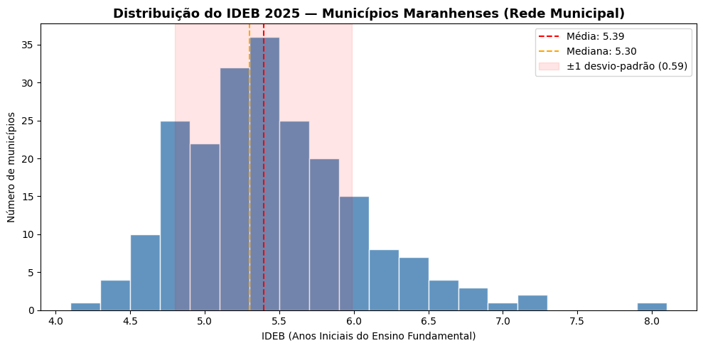

```
Distribuição do IDEB 2025:
  Municípios com dado: 216
  Média:   5.39
  Mediana: 5.30
  Desvio-padrão: 0.59
  Min: 4.10  |  Max: 8.10

============================================================
RANDOM FOREST — Importância de variáveis
============================================================
```

```
R² no treino: 0.846

Importância das variáveis (ordem decrescente):
  PCT_DOC_COM_SUPERIOR                          0.389  ██████████████████████████████████████
  RENDA_PER_CAPITA_2022                         0.334  █████████████████████████████████
  PCT_POBREZA_EXTREMA_2022                      0.277  ███████████████████████████
```

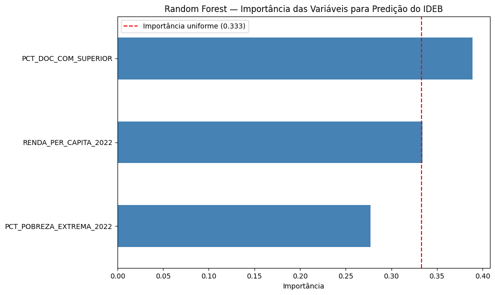

```python
analytics.distribuicao_ideb(df_cluster, salvar_arquivo=False)
analytics.random_forest(df_cluster, salvar_arquivo=False)

# Opcional: rodar pipeline completo de uma vez e salvar figuras
# analytics.main(salvar_graficos=True)
```

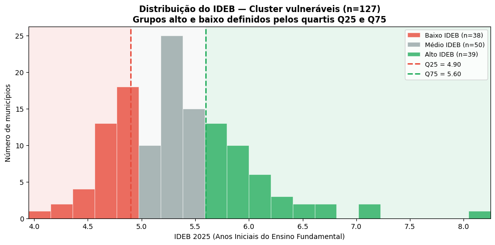

```
Distribuição por perfil — Cluster vulneráveis:
  Alto: n=39 | média=6.05 | [5.60–8.10]
  Médio: n=50 | média=5.27 | [5.00–5.50]
  Baixo: n=38 | média=4.69 | [4.10–4.90]
```

```python
# Distribuição do IDEB no cluster vulnerável com cortes por quartis
# Gerado em: reports/figures/distribuicao_quartis_vulneraveis.png
analytics.distribuicao_quartis_cluster(df_cluster, cluster_nome='vulneráveis', q=0.25, salvar_arquivo=False)
```